# Homework 02

## Question 1: Training and test error under a fixed design

Consider a linear regression problem with $n=100$ observations and $p=20$ available covariates. Generate one matrix $\mathbf X_{\mathrm{all}}\in\mathbb R^{n\times p}$ whose entries are independent $\mathcal N(0,1)$ random variables, and then keep this realized matrix fixed. Let

$$\beta_j=0.4^{\sqrt{j}},
\qquad j=1,\ldots,p,$$

and define

$$\boldsymbol\mu=\mathbf X_{\mathrm{all}}\boldsymbol\beta.$$

Generate one training response and one independent test response from

$$\begin{aligned}
\mathbf y
&=\boldsymbol\mu+\boldsymbol\epsilon,\\
\mathbf y^*
&=\boldsymbol\mu+\boldsymbol\epsilon^*,
\end{aligned}$$

where

$$\boldsymbol\epsilon,\boldsymbol\epsilon^*
\overset{\mathrm{ind}}{\sim}
\mathcal N_n(\mathbf 0,\mathbf I_n).$$

Here $\mathbf I_n$ is the $n\times n$ identity matrix.

For $m=0,1,\ldots,p$, fit a linear model with an intercept and the first $m$ columns of $\mathbf X_{\mathrm{all}}$ using $\mathbf y$. If $\widehat{\mathbf y}_m$ is its fitted mean vector, define

$$\operatorname{MSE}_{\mathrm{train},m}
=\frac{1}{n}
\left\lVert
\mathbf y-\widehat{\mathbf y}_m
\right\rVert_2^2,$$

and

$$\operatorname{MSE}_{\mathrm{test},m}
=\frac{1}{n}
\left\lVert
\mathbf y^*-\widehat{\mathbf y}_m
\right\rVert_2^2.$$

Use seed `43202` before generating $\mathbf X_{\mathrm{all}}$ and the response errors. R and Python use different random-number generators, so their exact numerical values need not agree.

1. For each $m$, calculate the average training and test MSE over the 200 simulation runs. Plot both curves against $m$. Verify numerically that training MSE does not increase as predictors are added in each simulation run.
2. For the model containing the first $m$ predictors, write

$$\mathbf X_m
=
[\mathbf 1,\mathbf x_1,\ldots,\mathbf x_m],
\qquad
\mathbf H_m
=
\mathbf X_m
(\mathbf X_m^{\mathsf T}\mathbf X_m)^{-1}
\mathbf X_m^{\mathsf T}.$$

Here $\mathbf X_m\in\mathbb R^{n\times(m+1)}$ and $\mathbf H_m\in\mathbb R^{n\times n}$. The model has $m+1$ fitted coefficients, including the intercept. Define its **total squared approximation bias** as

$$B_m^2
=\left\lVert
(\mathbf I_n-\mathbf H_m)\boldsymbol\mu
\right\rVert_2^2.$$

Thus, $B_m^2/n$ is the mean squared approximation bias.

Calculate the two theoretical expectations

$$E\!\left(
\operatorname{MSE}_{\mathrm{train},m}
\mid \mathbf X_{\mathrm{all}}
\right)
=\frac{B_m^2}{n}+1-\frac{m+1}{n},$$

and

$$E\!\left(
\operatorname{MSE}_{\mathrm{test},m}
\mid \mathbf X_{\mathrm{all}}
\right)
=\frac{B_m^2}{n}+1+\frac{m+1}{n}.$$

Add these expectations to your plot and compare them with the simulation averages.

3. Add the test MSE curve from one simulation run to the plot. Explain why this single curve is less smooth than the average test MSE. Use the approximation-bias and estimation-variance terms in the expected test MSE to explain why training MSE cannot be used by itself to select the predictor count.

### Solution: Question 1

**Show the starter code**

```r
set.seed(43202)

n <- 100
p <- 20
repetitions <- 100

X_all <- matrix(rnorm(n * p), nrow = n)

beta <- 0.4^sqrt(1:p)

mu <- as.vector(X_all %*% beta)

train_mse <- matrix(
  NA,
  nrow = repetitions,
  ncol = p + 1
)

test_mse <- matrix(
  NA,
  nrow = repetitions,
  ncol = p + 1
)

for(k in 1:repetitions){

  y_train <- mu + rnorm(n)
  y_test <- mu + rnorm(n)

  for (m in 0:p) {

    X_m <- cbind(1, X_all[, seq_len(m), drop = FALSE])

    fit <- lm.fit(x = X_m, y = y_train)
    y_hat <- as.vector(X_m %*% fit$coefficients)

    train_mse[k, m + 1] <- mean((y_train - y_hat)^2)
    test_mse[k, m + 1] <- mean((y_test - y_hat)^2)
  }
}

avg_train_mse <- colMeans(train_mse)
avg_test_mse <- colMeans(test_mse)

m_values <- 0:p

plot(
  m_values,
  avg_train_mse,
  type = "l",
  xlab = "Number of predictors (m)",
  ylab = "MSE",
  ylim = range(c(avg_train_mse, avg_test_mse))
)

lines(
  m_values,
  avg_test_mse,
  lty = 2
)

training_is_monotone <- all(
  apply(train_mse, 1, function(x) all(diff(x) <= 1e-10))
)

training_is_monotone
```

```
[1] TRUE
```

**Show the starter code**

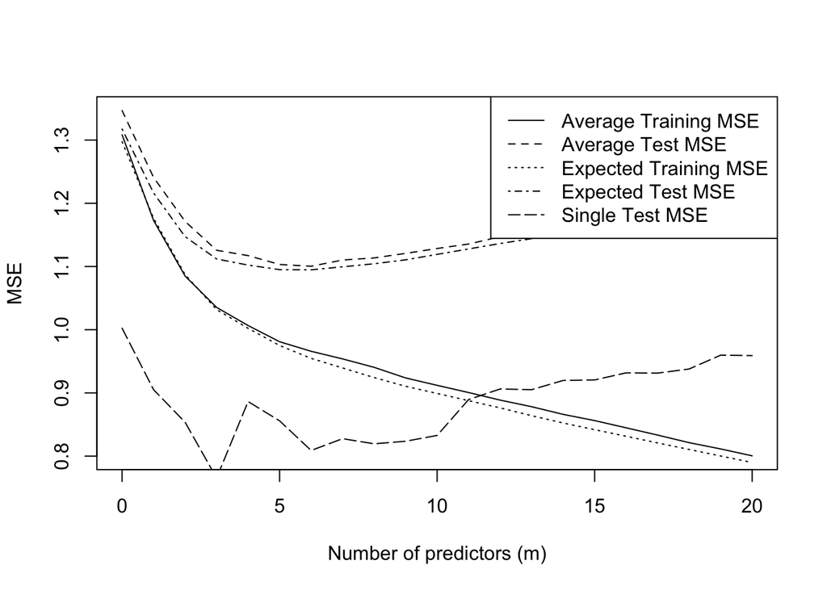

```r
theory_train <- numeric(p + 1)
theory_test <- numeric(p + 1)

for (m in 0:p) {

  X_m <- cbind(1, X_all[, seq_len(m), drop = FALSE])

  fit_mu <- lm.fit(x = X_m, y = mu)
  mu_hat <- as.vector(X_m %*% fit_mu$coefficients)

  bias_mse <- mean((mu - mu_hat)^2)

  theory_train[m + 1] <- bias_mse + 1 - (m + 1) / n
  theory_test[m + 1] <- bias_mse + 1 + (m + 1) / n
}

lines(m_values, theory_train, lty = 3)
lines(m_values, theory_test, lty = 4)

lines(
  m_values,
  test_mse[1, ],
  lty = 5
)

legend(
  "topright",
  legend = c(
    "Average Training MSE",
    "Average Test MSE",
    "Expected Training MSE",
    "Expected Test MSE",
    "Single Test MSE"
  ),
  lty = c(1, 2, 3, 4, 5)
)
```

## Question 2: Prediction error at one target point

Let $n=100$, $p=6$, and $\sigma^2=1$. Construct the fixed covariate matrix $\mathbf X_{\mathrm{all}}\in\mathbb R^{n\times p}$ with entries

$$(\mathbf X_{\mathrm{all}})_{ij}
=\sqrt{2}\cos\left\{
\frac{\pi j(i-\tfrac12)}{n}
\right\},
\qquad
i=1,\ldots,n,
\quad
j=1,\ldots,p.$$

Its columns satisfy

$$\mathbf 1^{\mathsf T}\mathbf X_{\mathrm{all}}=\mathbf 0^{\mathsf T},
\qquad
\frac{1}{n}\mathbf X_{\mathrm{all}}^{\mathsf T}\mathbf X_{\mathrm{all}}=\mathbf I_p.$$

Here $\mathbf I_p$ is the $p\times p$ identity matrix.

The following code shows a direct construction of $\mathbf X_{\mathrm{all}}$.

**R**

**Show the starter code**

```r
n <- 100
p <- 6
X_all <- outer(
  1:n, 1:p,
  function(i, j) sqrt(2) * cos(pi * j * (i - 0.5) / n)
)
```

**Python**

**Show the starter code**

```python
import numpy as np

n, p = 100, 6
i = np.arange(1, n + 1)[:, None]
j = np.arange(1, p + 1)[None, :]
X_all = np.sqrt(2) * np.cos(np.pi * j * (i - 0.5) / n)
```

Keep $\mathbf X_{\mathrm{all}}$ fixed and generate one training response from

$$\mathbf y
=\mathbf X_{\mathrm{all}}\boldsymbol\beta+\boldsymbol\epsilon,
\qquad
\boldsymbol\beta
=(0.5,0.5,0.5,0.5,0.5,0.5)^{\mathsf T},$$

where

$$\boldsymbol\epsilon
\sim
\mathcal N_n(\mathbf 0,\mathbf I_n).$$

Here $\mathbf I_n$ is the $n\times n$ identity matrix.

For $m=0,\ldots,p$, fit a linear model with an intercept and the first $m$ predictors. Consider prediction of the mean response at

$$\mathbf x_0=(0,1,0,0,1,0)^{\mathsf T}.$$

Write

$$\mu_0=\mathbf x_0^{\mathsf T}\boldsymbol\beta,$$

and let $\widehat\mu_{0,m}$ be the prediction from the model containing the first $m$ predictors. Here $x_{0j}$ denotes the $j$th coordinate of $\mathbf x_0$. For this design,

$$E\!\left[
\left(\widehat\mu_{0,m}-\mu_0\right)^2
\mid \mathbf X_{\mathrm{all}}
\right]
=
\left(
\sum_{j=m+1}^{p}x_{0j}\beta_j
\right)^2
+\frac{\sigma^2}{n}
\left(
1+\sum_{j=1}^{m}x_{0j}^2
\right).$$

1. Calculate $\mu_0$, the theoretical squared bias, and the expected squared error for $m=0,\ldots,p$ using the formula above. **You do not need to derive the formula.** Briefly explain in words why it consists of a squared bias term from omitted predictors and a variance term from estimating coefficients; no proof is required. Identify the values of $m$ where the expected squared error changes and where it remains unchanged.
2. Use seed `43203`. Generate the response, fit the models, and calculate

$$\left(\widehat\mu_{0,m}-\mu_0\right)^2.$$

Repeat this independently 200 times. Plot the simulation averages and theoretical expectations together. Report the smallest $m$ that minimizes the theoretical error.

3. All six regression coefficients are nonzero. Explain why only predictors 2 and 5 contribute directly to the mean response at $\mathbf x_0$. Contrast this target-specific error with the test MSE averaged over all rows of $\mathbf X_{\mathrm{all}}$ in Question 1.

### Solution: Question 2

**Show the starter code**

```r
n <- 100
p <- 6
sigma2 <- 1

X_all <- outer(
  1:n, 1:p,
  function(i, j) sqrt(2) * cos(pi * j * (i - 0.5) / n)
)

beta <- rep(0.5, p)
x0 <- c(0, 1, 0, 0, 1, 0)

mu0 <- sum(x0 * beta)

squared_bias <- numeric(p + 1)
expected_error <- numeric(p + 1)

for (m in 0:p) {

  if (m < p) {
    omitted <- (m + 1):p
    omitted_signal <- sum(x0[omitted] * beta[omitted])
  } else{
    omitted_signal <- 0
  }

  squared_bias[m + 1] <- omitted_signal^2

  estimation_variance <- sigma2 / n * (
    1 + sum(x0[seq_len(m)]^2)
  )

  expected_error[m + 1] <-
    squared_bias[m + 1] + estimation_variance
}

results_q2a <- data.frame(
  m = 0:p,
  squared_bias = squared_bias,
  expected_error = expected_error
)

results_q2a
```

```
  m squared_bias expected_error
1 0         1.00           1.01
2 1         1.00           1.01
3 2         0.25           0.27
4 3         0.25           0.27
5 4         0.25           0.27
6 5         0.00           0.03
7 6         0.00           0.03
```

**Show the starter code**

```r
set.seed(43203)

repetitions <- 200

mu <- as.vector(X_all %*% beta)

simulation_error <- matrix(
  NA,
  nrow = repetitions,
  ncol = p + 1
)

for (k in 1:repetitions) {

  y_train <- mu + rnorm(n)

  for (m in 0:p) {

    X_m <- cbind(1, X_all[, seq_len(m), drop = FALSE])

    fit <- lm.fit(x = X_m, y = y_train)

    target_row <- c(1, x0[seq_len(m)])

    mu0_hat <- sum(target_row * fit$coefficients)

    simulation_error[k, m + 1] <- (mu0_hat - mu0)^2
  }
}

simulated_error <- colMeans(simulation_error)

comparison_q2 <- data.frame(
  m = 0:p,
  simulated = simulated_error,
  theoretical = expected_error
)

comparison_q2
```

```
  m  simulated theoretical
1 0 1.01891864        1.01
2 1 1.01891864        1.01
3 2 0.26711699        0.27
4 3 0.26711699        0.27
5 4 0.26711699        0.27
6 5 0.03375873        0.03
7 6 0.03375873        0.03
```

**Show the starter code**

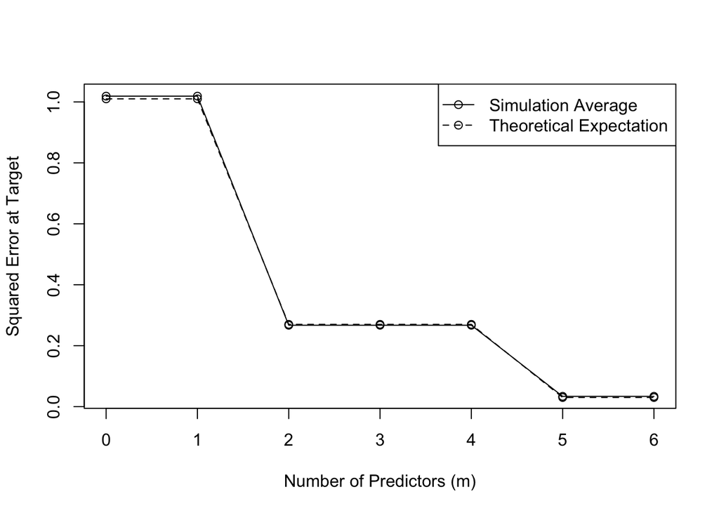

```r
plot(
  0:p,
  simulated_error,
  type = "o",
  xlab = "Number of Predictors (m)",
  ylab = "Squared Error at Target"
)

lines(
  0:p,
  expected_error,
  type = "o",
  lty = 2
)

legend(
  "topright",
  legend = c("Simulation Average", "Theoretical Expectation"),
  lty = c(1,2),
  pch = c(1,1)
)
```

**Show the starter code**

```r
which.min(expected_error) - 1
```

```
[1] 5
```

The squared bias comes from predictors that are omitted from the model but still contribute to the target mean. The variance term comes from estimating the intercept and included regression coefficients from noisy data. The expected squared error changes when predictors 2 and 5 are added because those are the only nonzero coordinates of (x_0). It remains unchanged when predictors 1, 3, 4, or 6 are added because their values at the target point are zero.

The simulation averages closely match the theoretical expected squared errors. The smallest value of (m) that minimizes the theoretical expected error is (m=5).

## Question 3: The optimism correction

Choose one candidate model before observing the response. Let $p$ be its number of predictors and let $\mathbf X\in\mathbb R^{n\times(p+1)}$ be its full-rank design matrix, including the intercept. The model has $p+1$ fitted coefficients. Let

$$\mathbf H
=\mathbf X
(\mathbf X^{\mathsf T}\mathbf X)^{-1}
\mathbf X^{\mathsf T}$$

be its hat matrix. Suppose

$$\mathbf y=\boldsymbol\mu+\boldsymbol\epsilon,
\qquad
\mathbf y^*=\boldsymbol\mu+\boldsymbol\epsilon^*,$$

Conditional on the fixed design $\mathbf X$, the two error vectors are independent, have mean zero, and have covariance matrix $\sigma^2\mathbf I_n$. Define

$$\operatorname{MSE}_{\mathrm{train}}
=
\frac{1}{n}
\left\lVert
\mathbf y-\mathbf H\mathbf y
\right\rVert_2^2,
\qquad
\operatorname{MSE}_{\mathrm{test}}
=
\frac{1}{n}
\left\lVert
\mathbf y^*-\mathbf H\mathbf y
\right\rVert_2^2.$$

The conditional bias vector of the fitted mean is

$$E(\mathbf H\mathbf y\mid\mathbf X)-\boldsymbol\mu
=
-(\mathbf I_n-\mathbf H)\boldsymbol\mu.$$

Let $B^2$ denote the **total squared approximation bias**:

$$B^2
=\left\lVert
(\mathbf I_n-\mathbf H)\boldsymbol\mu
\right\rVert_2^2.$$

Thus, $B^2/n$ is the mean squared approximation bias.

You may use

$$\mathbf H^{\mathsf T}=\mathbf H,
\qquad
\mathbf H^2=\mathbf H,
\qquad
\operatorname{tr}(\mathbf H)=p+1.$$

For any fixed matrix $\mathbf A$, you may also use

$$E\!\left(
\boldsymbol\epsilon^{\mathsf T}
\mathbf A
\boldsymbol\epsilon
\mid \mathbf X
\right)
=\sigma^2\operatorname{tr}(\mathbf A).$$

1. Derive

$$E(\operatorname{MSE}_{\mathrm{train}}\mid\mathbf X)
=\frac{B^2}{n}
+\sigma^2\left(1-\frac{p+1}{n}\right),$$

and

$$E(\operatorname{MSE}_{\mathrm{test}}\mid\mathbf X)
=\frac{B^2}{n}
+\sigma^2\left(1+\frac{p+1}{n}\right).$$

2. Deduce the expected optimism, defined as $E(\operatorname{MSE}_{\mathrm{test}}-\operatorname{MSE}_{\mathrm{train}}\mid\mathbf X)$. For

$$n=120,
\qquad
p=4,
\qquad
\frac{B^2}{n}=0.04,
\qquad
\sigma^2=1,$$

calculate the expected training MSE, expected test MSE, and their difference. Explain why the ordering need not hold for every realized pair of responses.

3. Continue with $n=120$ and $p=4$. Suppose the candidate model has residual sum of squares $\operatorname{RSS}=116.4$, and suppose a common estimate of the error variance is $\widehat\sigma^2=0.96$.

Calculate

$$\widehat{\operatorname{MSE}}_{\mathrm{test}}
=\frac{
\operatorname{RSS}+2(p+1)\widehat\sigma^2
}{n},$$

and

$$C_p
=\frac{\operatorname{RSS}}{\widehat\sigma^2}
-n+2(p+1).$$

Show how these two quantities are related, and explain why minimizing $C_p$ is equivalent to minimizing the corrected test MSE when $n$ and $\widehat\sigma^2$ are common to all candidate models.

### Solution: Question 3

Training MSE:

$$\mathbf{y} - \mathbf{Hy} = (\mathbf{I}_n - \mathbf{H})(\boldsymbol{\mu} + \boldsymbol{\epsilon}) = (\mathbf{I}_n - \mathbf{H}) \boldsymbol{\mu}+(\mathbf{I}_n - \mathbf{H})\boldsymbol{\epsilon}$$

$$E(||\mathbf{y} - \mathbf{Hy}||^2_2 |\mathbf{X}) = B^2 + \sigma^2tr(\mathbf{I}_n - \mathbf{H})$$

$$= B^2 + \sigma^2(n - (p + 1))$$
$$E(MSE_{train}|\mathbf{X}) = \frac{B^2}{n} + \sigma^2(1 - \frac{p + 1}{n})$$

Testing MSE:

$$\mathbf{y^*} - \mathbf{Hy} = (\mathbf{I}_n - \mathbf{H})\boldsymbol{\mu}+\boldsymbol{\epsilon^*}-\mathbf{H}\boldsymbol{\epsilon}$$
$$E(||\boldsymbol{\epsilon^*}-\mathbf{H}\boldsymbol{\epsilon}||^2_2|\mathbf{X}) = n\sigma^2+\sigma^2tr(\mathbf{H}) = \sigma^2(n + p + 1)$$
$$E(||\mathbf{y^*} - \mathbf{Hy}||^2_2 |\mathbf{X}) = B^2 + \sigma^2(n+p+1)$$
$$E(MSE_{test}|\mathbf{X}) = \frac{B^2}{n} + \sigma^2(1 + \frac{p+1}{n})$$

$$E(MSE_{test}|\mathbf{X}) - E(MSE_{train}|\mathbf{X}) = \frac{2(p+1)\sigma^2}{n}$$

**Show the starter code**

```r
MSE_train <- 0.04 + 1 - (5/120)
MSE_test <- 0.04 + 1 + (5/120)
optimism <- MSE_test - MSE_train
MSE_train
```

```
[1] 0.9983333
```

**Show the starter code**

```r
MSE_test
```

```
[1] 1.081667
```

**Show the starter code**

```r
optimism
```

```
[1] 0.08333333
```

This ordering does not have to occur for every individual pair of responses because these are expected values over many possible responses. Random variation could cause the test MSE to be smaller than the training MSE in a particular case.

**Show the starter code**

```r
n <- 120
p <- 4
RSS <- 116.4
sigma2_hat <- 0.96

corrected_test_mse <- (
  RSS + 2 * (p + 1) * sigma2_hat
) / n

Cp <- RSS / sigma2_hat - n + 2 * (p + 1)

corrected_test_mse
```

```
[1] 1.05
```

**Show the starter code**

```r
Cp
```

```
[1] 11.25
```

The corrected test MSE is 1.05, and Mallows’ Cp is 11.25. These two quantities are related because using the Cp value of 11.25 in the corrected test MSE calculation also gives 1.05. When the sample size and estimated error variance are the same for all candidate models, minimizing Cp is equivalent to minimizing the corrected test MSE because both criteria will rank the models in the same order.

## Question 4: Comparing Mallows’ $C_p$, AIC, and BIC

Use `data/diabetes.csv`, with `y` as the response. Use rows 1 through 370 as the training data, and let $n=370$ denote the training sample size. Do not use rows 371 through 442 in this question. Fit the following ordinary least-squares models, each with an intercept.

| Model | Predictors | $p$ |
| --- | --- | --- |
| Model A | `bmi`, `bp`, `s5`, `sex`, `s1`, `s2`, `s4` | 7 |
| Model B | all predictors in Model A, followed by `s6` | 8 |
| Full reference | all ten predictors | 10 |

Here $p$ counts predictors, so each model has $p+1$ fitted coefficients including the intercept. Estimate one common noise variance from the full reference model, using $p=10$:

$$\widehat\sigma^2
=\frac{\operatorname{RSS}_{\mathrm{full}}}{n-(p+1)}.$$

For Models A and B, calculate

$$C_p
=\frac{\operatorname{RSS}}{\widehat\sigma^2}
-n+2(p+1),$$

$$\operatorname{AIC}^{\mathrm{red}}
=n\log\left(\frac{\operatorname{RSS}}{n}\right)+2(p+1),$$

and

$$\operatorname{BIC}^{\mathrm{red}}
=n\log\left(\frac{\operatorname{RSS}}{n}\right)
+(p+1)\log(n).$$

The reduced AIC and BIC omit constants shared by the two candidate models. Smaller values are preferred within each criterion.

1. Fit the three models. Report $p$, RSS, the residual degrees of freedom of the full model, and $\widehat\sigma^2$.
2. Calculate $C_p$, reduced AIC, and reduced BIC for Models A and B. State which model each criterion selects. Do not compare numerical values across different criteria.
3. Compare the improvement in fit from adding `s6` with the one-parameter penalty under each criterion. Use this comparison to explain any disagreement. Why does selecting a model not establish that it is the true data-generating model?

### Solution: Question 4

**Show the starter code**

```r
diabetes <- read.csv("data/diabetes.csv")
training <- diabetes[1:370, ]

model_A <- lm(y ~ bmi + bp + s5 + sex + s1 + s2 + s4,
              data = training)

model_B <- lm(y ~ bmi + bp + s5 + sex + s1 + s2 + s4 + s6,
              data = training)

model_full <- lm(y ~ age + sex + bmi + bp + s1 + s2 + s3 + s4 + s5 + s6,
                 data = training)

RSS_A <- sum(residuals(model_A)^2)
RSS_B <- sum(residuals(model_B)^2)
RSS_full <- sum(residuals(model_full)^2)

residual_df <- 370 - (10 + 1)
sigma2_hat <- RSS_full / residual_df

RSS_A
```

```
[1] 1098909
```

**Show the starter code**

```r
RSS_B
```

```
[1] 1089717
```

**Show the starter code**

```r
RSS_full
```

```
[1] 1089452
```

**Show the starter code**

```r
residual_df
```

```
[1] 359
```

**Show the starter code**

```r
sigma2_hat
```

```
[1] 3034.684
```

**Show the starter code**

```r
p_A <- 7
p_B <- 8
n <- 370

Cp_A <- RSS_A / sigma2_hat - n + 2 * (p_A + 1)
Cp_B <- RSS_B / sigma2_hat - n + 2 * (p_B + 1)

AIC_A <- n * log(RSS_A / n) + 2 * (p_A + 1)
AIC_B <- n * log(RSS_B / n) + 2 * (p_B + 1)

BIC_A <- n * log(RSS_A / n) + (p_A + 1) * log(n)
BIC_B <- n * log(RSS_B / n) + (p_B + 1) * log(n)

Cp_A
```

```
[1] 8.116253
```

**Show the starter code**

```r
Cp_B
```

```
[1] 7.087434
```

**Show the starter code**

```r
AIC_A
```

```
[1] 2974.64
```

**Show the starter code**

```r
AIC_B
```

```
[1] 2973.532
```

**Show the starter code**

```r
BIC_A
```

```
[1] 3005.948
```

**Show the starter code**

```r
BIC_B
```

```
[1] 3008.754
```

**Show the starter code**

```r
fit_gain <- n * log(RSS_A / RSS_B)
cp_gain <- (RSS_A - RSS_B) / sigma2_hat

fit_gain
```

```
[1] 3.107775
```

**Show the starter code**

```r
cp_gain
```

```
[1] 3.028819
```

**Show the starter code**

```r
log(n)
```

```
[1] 5.913503
```

Model A has 7 predictors and an RSS of 1,098,909. Model B has 8 predictors and an RSS of 1,089,717. The full reference model has 10 predictors and an RSS of 1,089,452. The full model has 359 residual degrees of freedom. Using the full model, the estimated common noise variance is 3,034.684.

Mallows’ Cp selects Model B because it has the smaller Cp value of 7.087 compared to 8.116 for Model A. Reduced AIC also selects Model B because its value of 2973.532 is smaller than 2974.640 for Model A. Reduced BIC selects Model A because its value of 3005.948 is smaller than 3008.754 for Model B.

The improvement in fit from adding s6 is about 3.108 on the AIC and BIC scale. This is larger than AIC’s additional penalty of 2, so AIC selects Model B, but it is smaller than BIC’s additional penalty of about 5.914, so BIC selects Model A. For Mallows’ Cp, the improvement in fit is about 3.029, which is larger than its additional penalty of 2, so Cp also selects Model B.

Selecting one of these models does not prove that it is the true data-generating model. The criteria only compare the candidate models under the assumptions being used and choose the one that performs best according to that particular criterion.

## Question 5: Validation and final test data

Use rows 1 through 370 of `diabetes.csv` as the training data and rows 371 through 442 as the final test data. Consider eleven nested candidate models. For $m=0,1,\ldots,10$, the model with $m$ predictors contains an intercept and the first $m$ predictors in this order:

`age`, `sex`, `bmi`, `bp`, `s1`, `s2`, `s3`, `s4`, `s5`, `s6`.

An analyst proposes the following procedure:

1. Fit all eleven candidate models using the training data.
2. Calculate the MSE of each model on the final test data.
3. Select the model with the smallest test MSE.
4. Report that minimum as the final estimate of prediction error.

The analyst argues that the procedure is valid because the final test data were not used to estimate the regression coefficients.

1. Identify the first step that misuses the final test data. Explain why the minimum of eleven test MSE values is generally too favorable as an estimate of the selected procedure’s future prediction error.
2. Rewrite the analysis using five-fold cross-validation within the training data. State how the predictor count is selected, what is refitted, and when the final test data may be used.
3. Suppose the analyst has already examined all eleven test MSE values. What can still be reported transparently, and what additional data would be needed for a new final evaluation?

### Solution: Question 5

The first misuse of the final test data occurs in Step 2, when the analyst calculates the test MSE for all eleven candidate models. The final test set is supposed to be used only after the model selection procedure has been completed. By comparing the eleven test MSE values, the analyst is using the test data to help select the number of predictors.

The minimum of the eleven test MSE values is generally too favorable because each test MSE is affected by random variation. Selecting the smallest value tends to choose a model whose test MSE happened to be unusually low by chance. Reporting that same minimum as the final prediction error therefore gives an overly optimistic estimate of future prediction error.

First, rows 371 through 442 should be set aside as the final test data and should not be used during model selection. The 370 training observations should then be divided into five folds. For each of the eleven possible predictor counts, the model should be fit using four folds and evaluated on the remaining fold. This process is repeated until each fold has been used as the validation fold.

The five validation MSE values should then be averaged for each predictor count, and the predictor count with the smallest average validation MSE should be selected. The selected model should then be refit using all 370 training observations. Finally, the final test data can be used once to evaluate the prediction error of this fitted model.

If the analyst has already examined all eleven final test MSE values, the results can still be reported as an exploratory analysis. However, the minimum test MSE should not be reported as an unbiased final estimate of prediction error because the test data were already used during model selection. A new independent test dataset or future observations would be needed to perform a new final evaluation of the selected model.

## Reference

James, Witten, Hastie, Tibshirani, and Taylor, [*An Introduction to Statistical Learning*](https://www.statlearning.com/), Chapters 3, 5, and 6.